# HW#2_Data412_SydneyBall

## Question 7

Another more specfici scatterplot

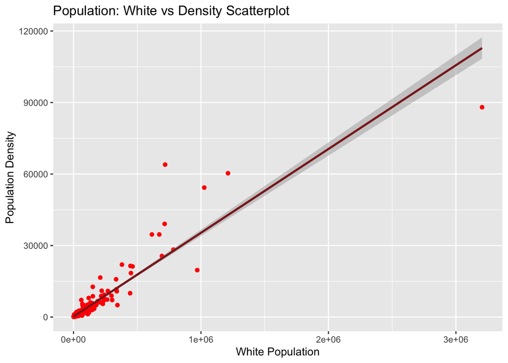

```r
ggplot(data=midwest) +
  geom_point(mapping = aes(x=popwhite, y=popdensity), color = 'red') +
  xlab("White Population") +
  ylab("Population Density") +
  ggtitle("Population: White vs Density Scatterplot") +
  geom_smooth(method=lm, mapping=aes(x=popwhite,y=popdensity), color = 'brown4')
```

## Question 8

Write the code that will develop this scatterplot with the smooth regression lines

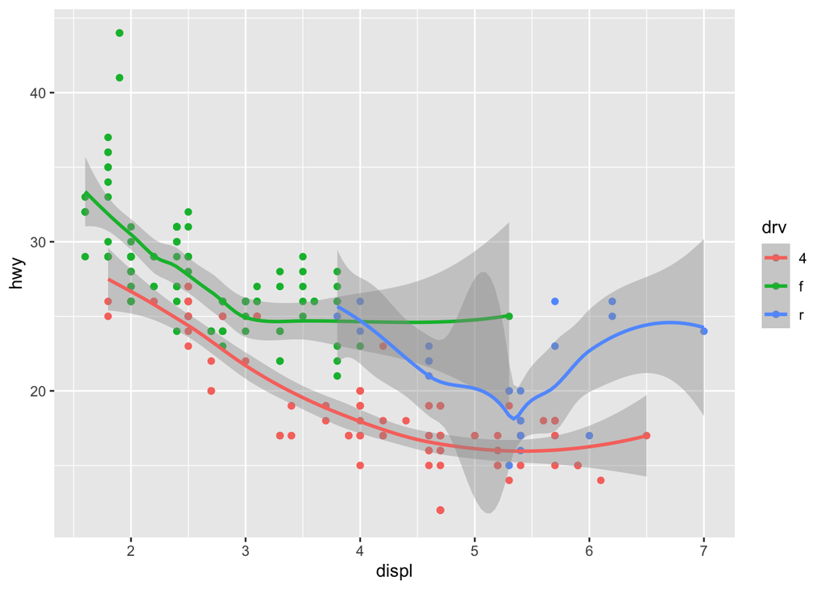

```r
ggplot(data=mpg) +
  geom_point(mapping = aes(x = displ, y=hwy, color = drv)) +
  geom_smooth(mapping = aes(x = displ, y=hwy, color = drv))
```

## Question 9

Develop code that will produce a facet grid of population density by state

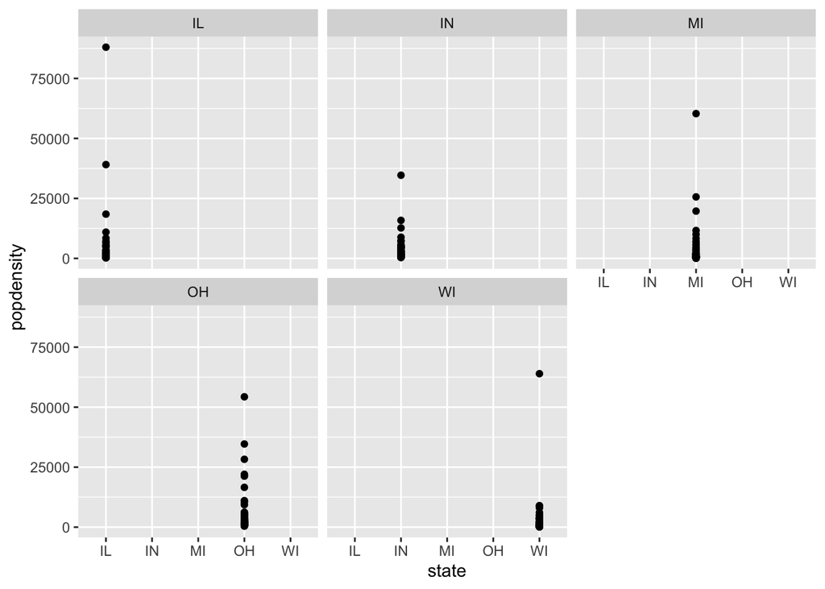

```r
ggplot(data=midwest, mapping=(aes(x=state,y=popdensity))) +
  geom_point() +
  facet_wrap(~state)
```

I am not quite sure what the independent variable on the x-axis is because there is no label in the image. I tried to problem solve with different variables but couldn’t find a fit.

## Question 10

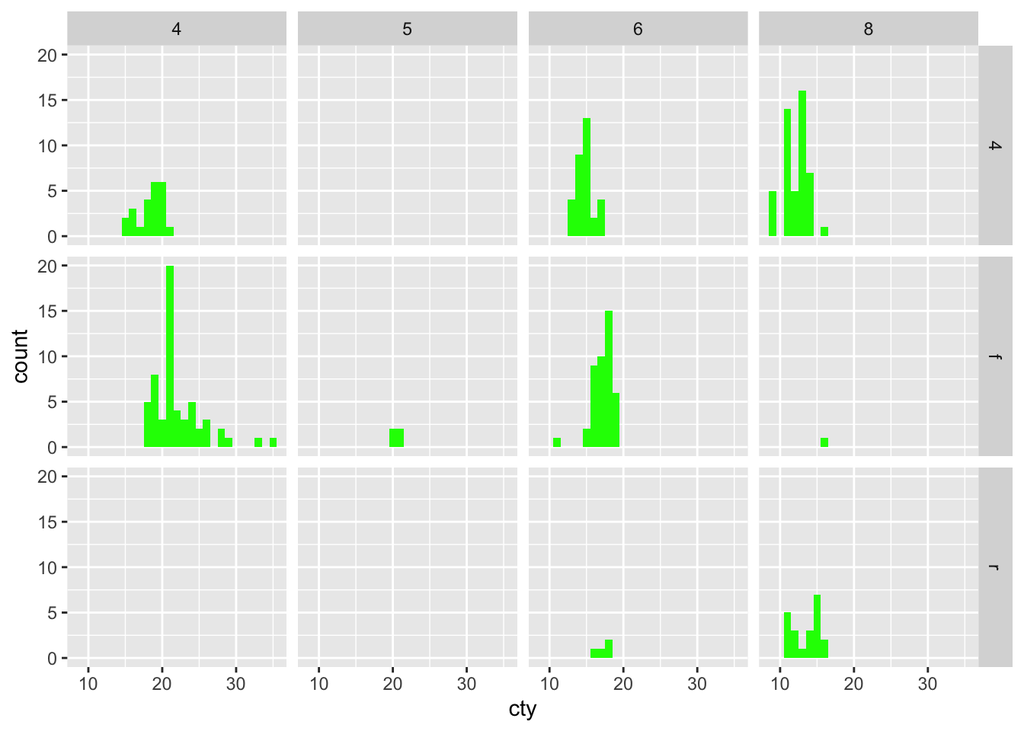

```r
ggplot(data = mpg) +
  geom_histogram(mapping= aes(x=cty), fill = 'green', binwidth = 1) +
  facet_grid(drv~cyl)
```